# Principios y Prácticas de SEM y MLM (5ed)

Tema 1.3 Análisis de Moderación

Author

Efraín García Sánchez

Published

August 5, 2026

# Práctica

## Preparar el ambiente de trabajo (instalar, si no están instalados)

```r
# install.packages("tidyverse")        # manipulación y visualización de datos
# install.packages("easystats")        # Paquetes para análisis estadísticos
# install.packages("sjPlot")           # para visualización de resultados
# install.packages("sjmisc")           # funciones para manipulación de datos
# install.packages("marginaleffects")  # estimar predicciones, contrastes y pendientes
# install.packages("emmeans")          # estima medias marginales
# install.packages("sjPlot")           # para reportar tablas y figuras
```

## Preparar el ambiente de trabajo (cargar los paquetes)

```r
library(tidyverse)        # manipulación y visualización de datos
library(easystats)        # Paquetes para análisis estadísticos
library(sjPlot)           # para visualización de resultados
library(sjmisc)           # funciones para manipulación de datos
library(marginaleffects)  # estimar predicciones, contrastes y pendientes
library(emmeans)          # estima medias marginales
library(sjPlot)           # para reportar tablas y figuras
```

## Importar los datos: con etiquetas (para conservar los labels)

```r
data_labels <- haven::read_sav(
  here::here("data/northampton_student_health_data_package/northampton_student_health_labelled.sav"))

glimpse(data_labels)
```

```
Rows: 590
Columns: 61
$ id                             <dbl> 1, 2, 3, 4, 5, 6, 7, 8, 9, 10, 11, 12, …
$ age_group                      <dbl+lbl> 1, 1, 1, 1, 1, 1, 2, 4, 1, 1, 1, 1,…
$ gender                         <dbl+lbl> 2, 1, 1, 1, 1, 2, 1, 1, 2, 2, 2, 2,…
$ sexual_orientation             <dbl+lbl> 1, 2, 1, 3, 1, 1, 1, 1, 1, 1, 1, 1,…
$ ethnicity                      <dbl+lbl> 1, 1, 1, 2, 1, 3, 1, 1, 1, 3, 1, 1,…
$ study_mode                     <dbl+lbl> 1, 1, 1, 1, 1, 1, 1, 2, 1, 1, 1, 1,…
$ study_level                    <dbl+lbl> 3, 3, 3, 3, 2, 6, 4, 3, 1, 2, 1, 1,…
$ living_situation               <dbl+lbl> 1, 2, 1, 3, 2, 4, 3, 3, 1, 2, 4, 1,…
$ phys_health                    <dbl+lbl> 3, 4, 4, 3, 4, 5, 5, 1, 4, 4, 4, 5,…
$ ment_health                    <dbl+lbl> 4, 3, 2, 4, 3, 3, 2, 1, 4, 4, 3, 5,…
$ social_connect                 <dbl+lbl> 4, 3, 1, 1, 2, 3, 2, 4, 4, 3, 3, 3,…
$ sitting_weekday_hours          <dbl> 8, 5, 7, 9, NA, 5, 11, 13, 6, 5, 12, 6,…
$ sleep_quality                  <dbl> 8, 7, 4, 7, 2, 5, 3, 8, 7, 2, 9, 7, 3, …
```

[output cut: 48 more lines]

## Importar los datos: solo numéricos (para facilitar la manipulación)

```r
data <- readr::read_csv(
  here::here("data/northampton_student_health_data_package/northampton_student_health_numeric.csv"))

glimpse(data)
```

```
Rows: 590
Columns: 61
$ id                             <dbl> 1, 2, 3, 4, 5, 6, 7, 8, 9, 10, 11, 12, …
$ age_group                      <dbl> 1, 1, 1, 1, 1, 1, 2, 4, 1, 1, 1, 1, 1, …
$ gender                         <dbl> 2, 1, 1, 1, 1, 2, 1, 1, 2, 2, 2, 2, 2, …
$ sexual_orientation             <dbl> 1, 2, 1, 3, 1, 1, 1, 1, 1, 1, 1, 1, 1, …
$ ethnicity                      <dbl> 1, 1, 1, 2, 1, 3, 1, 1, 1, 3, 1, 1, 1, …
$ study_mode                     <dbl> 1, 1, 1, 1, 1, 1, 1, 2, 1, 1, 1, 1, 1, …
$ study_level                    <dbl> 3, 3, 3, 3, 2, 6, 4, 3, 1, 2, 1, 1, 1, …
$ living_situation               <dbl> 1, 2, 1, 3, 2, 4, 3, 3, 1, 2, 4, 1, 1, …
$ phys_health                    <dbl> 3, 4, 4, 3, 4, 5, 5, 1, 4, 4, 4, 5, 5, …
$ ment_health                    <dbl> 4, 3, 2, 4, 3, 3, 2, 1, 4, 4, 3, 5, 3, …
$ social_connect                 <dbl> 4, 3, 1, 1, 2, 3, 2, 4, 4, 3, 3, 3, 2, …
$ sitting_weekday_hours          <dbl> 8, 5, 7, 9, NA, 5, 11, 13, 6, 5, 12, 6,…
$ sleep_quality                  <dbl> 8, 7, 4, 7, 2, 5, 3, 8, 7, 2, 9, 7, 3, …
```

[output cut: 48 more lines]

## Transformar los datos y recodificar variables (igual que antes)

```r
data <- data |>
  mutate(# creo variable dummy para género (Female vs Male)
         gender_female = case_when(gender == 1 ~ 1, # Female
                                   gender == 2 ~ 0, # Male
                                   .default = NULL),
         # creo una variable de etnia para los grupos más grandes
         ethnicity_cat = case_when(ethnicity == 1 ~ "White",
                                 ethnicity == 3 ~ "Black",
                                 ethnicity == 4 ~ "Asian",
                                 TRUE ~ NA_character_),
         # ordeno la variable de etnia en niveles (White es la referencia)
         ethnicity_cat = factor(ethnicity_cat,
                                levels = c("White", "Black", "Asian")),
         # Creo una variable dummy para ver diferencias con White
         ethnicity_black = ifelse(test = ethnicity_cat == "Black",
                                  yes = 1, no = 0),
         ethnicity_asian = ifelse(test = ethnicity_cat == "Asian",
                                  yes = 1, no = 0),
         # creo una variable categórica con pa_activity
         pa_activity_level_cat = case_when(pa_activity_level == 0 ~ "0_Inactive",
                                       pa_activity_level == 1 ~ "1_Fairly_Active",
                                       pa_activity_level == 2 ~ "2_Active")
         )
```

## Centrar las variables

```r
data <- data |>
  mutate(
    # manualmente
    alcohol_freq_cen = as.numeric(scale(alcohol_freq, center = TRUE, scale = FALSE)),
    alcohol_freq_z = as.numeric(scale(alcohol_freq, center = TRUE, scale = TRUE))
    )
```

```r
# visualizar los datos
data |>
  dplyr::select(alcohol_freq, alcohol_freq_cen, alcohol_freq_z)
```

| alcohol_freq | alcohol_freq_cen | alcohol_freq_z |
| --- | --- | --- |
| 2 | 0.5152542 | 0.3028104 |
| 1 | -0.4847458 | -0.2848809 |
| 1 | -0.4847458 | -0.2848809 |
| 1 | -0.4847458 | -0.2848809 |
| 4 | 2.5152542 | 1.4781930 |
| 1 | -0.4847458 | -0.2848809 |
| 1 | -0.4847458 | -0.2848809 |
| 5 | 3.5152542 | 2.0658844 |
| 5 | 3.5152542 | 2.0658844 |
| 1 | -0.4847458 | -0.2848809 |

[output cut: 580 more lines]

```r
# visualizar los datos
data |>
  dplyr::select(alcohol_freq, alcohol_freq_cen, alcohol_freq_z) |>
  psych::describe()
```

|  | vars | n | mean | sd | median | trimmed | mad | min | max | range | skew | kurtosis | se |
| --- | --- | --- | --- | --- | --- | --- | --- | --- | --- | --- | --- | --- | --- |
| alcohol_freq | 1 | 590 | 1.484746e+00 | 1.701574 | 1.0000000 | 1.2394068 | 1.4826000 | 0.0000000 | 7.000000 | 7.000000 | 0.9353456 | -0.2941042 | 0.07005268 |
| alcohol_freq_cen | 2 | 590 | -4.538742e-16 | 1.701574 | -0.4847458 | -0.2453390 | 1.4826000 | -1.4847458 | 5.515254 | 7.000000 | 0.9353456 | -0.2941042 | 0.07005268 |
| alcohol_freq_z | 3 | 590 | 9.408670e-18 | 1.000000 | -0.2848809 | -0.1441836 | 0.8713111 | -0.8725722 | 3.241267 | 4.113839 | 0.9353456 | -0.2941042 | 0.04116935 |

## Modelos de regresión lineal: efectos simples

```r
m0 <- lm(ment_health ~ 1, data = data)

m1 <- lm(ment_health ~ alcohol_freq + pa_activity_level, data = data)

m2 <- lm(ment_health ~ alcohol_freq_cen + pa_activity_level,data = data)

m3 <- lm(ment_health ~ alcohol_freq_z + pa_activity_level,data = data)

# ver los resultados
parameters::compare_parameters(m0, m1, m2, m3) |>
  parameters::display()
```

| Parameter | m0 | m1 | m2 | m3 |
| --- | --- | --- | --- | --- |
| (Intercept) | 3.45 (3.36, 3.53) | 3.36 ( 3.16, 3.56) | 3.23 ( 3.04, 3.42) | 3.23 ( 3.04, 3.42) |
| pa activity level |  | 0.18 ( 0.04, 0.32) | 0.18 ( 0.04, 0.32) | 0.18 ( 0.04, 0.32) |
| alcohol freq |  | -0.09 (-0.14, -0.04) |  |  |
| alcohol freq cen |  |  | -0.09 (-0.14, -0.04) |  |
| alcohol freq z |  |  |  | -0.15 (-0.23, -0.06) |
| Observations | 590 | 590 | 590 | 590 |

## Inspeccionar los resultados

```r
sjPlot::tab_model(m0, m1, m2, m3,
                  show.ci = FALSE,
                  dv.labels = c("M0. (intercepto = media)",
                                "M1. (Datos brutos)",
                                "M2. (Variable centrada)",
                                "M3.(Variable centrada y estandarizada"),
                  show.stat = TRUE)
```

|  | M0. (intercepto = media) |  |  | M1. (Datos brutos) |  |  | M2. (Variable centrada) |  |  | M3.(Variable centrada y estandarizada |  |  |
| --- | --- | --- | --- | --- | --- | --- | --- | --- | --- | --- | --- | --- |
| Predictors | Estimates | Statistic | p | Estimates | Statistic | p | Estimates | Statistic | p | Estimates | Statistic | p |
| (Intercept) | 3.45 | 79.48 | **<0.001** | 3.36 | 33.72 | **<0.001** | 3.23 | 34.02 | **<0.001** | 3.23 | 34.02 | **<0.001** |
| alcohol freq |  |  |  | -0.09 | -3.43 | **0.001** |  |  |  |  |  |  |
| pa activity level |  |  |  | 0.18 | 2.55 | **0.011** | 0.18 | 2.55 | **0.011** | 0.18 | 2.55 | **0.011** |
| alcohol freq cen |  |  |  |  |  |  | -0.09 | -3.43 | **0.001** |  |  |  |
| alcohol freq z |  |  |  |  |  |  |  |  |  | -0.15 | -3.43 | **0.001** |
| Observations | 590 |  |  | 590 |  |  | 590 |  |  | 590 |  |  |
| R<sup>2</sup> / R<sup>2</sup> adjusted | 0.000 / 0.000 |  |  | 0.028 / 0.025 |  |  | 0.028 / 0.025 |  |  | 0.028 / 0.025 |  |  |

- El intercepto cambia: la media de `Y` cuando el predictor es `0`
- El coeficiente de regresión no cambia si la variable está centrada o no
- El coeficiente cambia cuando se estandariza (la unidad de medida ha cambiado)
- La Varianza explicada no cambia

## Comparar los modelos

- El `m0` difiere de `m1`, pero de resto son iguales

```r
anova(m0, m1, m2, m3)
```

|  | Res.Df | RSS | Df | Sum of Sq | F | Pr(>F) |
| --- | --- | --- | --- | --- | --- | --- |
| 1 | 589 | 653.8712 | NA | NA | NA | NA |
| 2 | 587 | 635.4935 | 2 | 1.837765e+01 | 8.487639 | 0.0002323584 |
| 3 | 587 | 635.4935 | 0 | 0.000000e+00 | NA | NA |
| 4 | 587 | 635.4935 | 0 | -1.136868e-13 | NA | NA |

## Comparar los modelos `performance::compare_performance()`

```r
performance::compare_performance(m0, m1, m2, m3) |>
  parameters::display()
```

| Name | Model | AIC (weights) | AICc (weights) | BIC (weights) | R2 | R2 (adj.) | RMSE | Sigma |
| --- | --- | --- | --- | --- | --- | --- | --- | --- |
| m0 | lm | 1739.0 (<.001) | 1739.0 (<.001) | 1747.8 (0.04) | 0.00 | 0.00 | 1.05 | 1.05 |
| m1 | lm | 1726.2 (0.33) | 1726.2 (0.33) | 1743.7 (0.32) | 0.03 | 0.02 | 1.04 | 1.04 |
| m2 | lm | 1726.2 (0.33) | 1726.2 (0.33) | 1743.7 (0.32) | 0.03 | 0.02 | 1.04 | 1.04 |
| m3 | lm | 1726.2 (0.33) | 1726.2 (0.33) | 1743.7 (0.32) | 0.03 | 0.02 | 1.04 | 1.04 |

## Modelos de regresión lineal: efectos combinados (interacción)

```r
m1a <- lm(ment_health ~ alcohol_freq*pa_activity_level,
         data = data)

m2a <- lm(ment_health ~ alcohol_freq_cen*pa_activity_level,
         data = data)

m3a <- lm(ment_health ~ alcohol_freq_z*pa_activity_level,
         data = data)

parameters::compare_parameters(m1, m1a, m2, m2a, m3, m3a) |>
  parameters::display()
```

| Parameter | m1 | m1a | m2 | m2a | m3 | m3a |
| --- | --- | --- | --- | --- | --- | --- |
| (Intercept) | 3.36 ( 3.16, 3.56) | 3.11 ( 2.87, 3.34) | 3.23 ( 3.04, 3.42) | 3.25 ( 3.06, 3.43) | 3.23 ( 3.04, 3.42) | 3.25 ( 3.06, 3.43) |
| pa activity level | 0.18 ( 0.04, 0.32) | 0.41 ( 0.22, 0.59) | 0.18 ( 0.04, 0.32) | 0.18 ( 0.04, 0.32) | 0.18 ( 0.04, 0.32) | 0.18 ( 0.04, 0.32) |
| alcohol freq | -0.09 (-0.14, -0.04) | 0.10 (-0.01, 0.20) |  |  |  |  |
| alcohol freq × pa activity level |  | -0.15 (-0.23, -0.07) |  |  |  |  |
| alcohol freq cen |  |  | -0.09 (-0.14, -0.04) | 0.10 (-0.01, 0.20) |  |  |
| alcohol freq cen × pa activity level |  |  |  | -0.15 (-0.23, -0.07) |  |  |
| alcohol freq z |  |  |  |  | -0.15 (-0.23, -0.06) | 0.16 (-0.02, 0.35) |
| alcohol freq z × pa activity level |  |  |  |  |  | -0.26 (-0.40, -0.12) |
| Observations | 590 | 590 | 590 | 590 | 590 | 590 |

## Modelos de regresión lineal: efectos combinados (interacción)

```r
sjPlot::tab_model(m1, m1a, m2, m2a, m3, m3a,
                  dv.labels = c("M1. (Datos brutos)","M1a. (Datos brutos + interacción)",
                                "M2. (centrada)","M2a. (centrada + interacción)",
                                "M3.(estandarizada","M3a. (estandarizada + interacción)"),
                  show.ci = FALSE,
                  show.p = FALSE)
```

|  | M1. (Datos brutos) | M1a. (Datos brutos + interacción) | M2. (centrada) | M2a. (centrada + interacción) | M3.(estandarizada | M3a. (estandarizada + interacción) |
| --- | --- | --- | --- | --- | --- | --- |
| Predictors | Estimates | Estimates | Estimates | Estimates | Estimates | Estimates |
| (Intercept) | 3.36 | 3.11 | 3.23 | 3.25 | 3.23 | 3.25 |
| alcohol freq | -0.09 | 0.10 |  |  |  |  |
| pa activity level | 0.18 | 0.41 | 0.18 | 0.18 | 0.18 | 0.18 |
| alcohol freq × pa activity level |  | -0.15 |  |  |  |  |
| alcohol freq cen |  |  | -0.09 | 0.10 |  |  |
| alcohol freq cen × pa activity level |  |  |  | -0.15 |  |  |
| alcohol freq z |  |  |  |  | -0.15 | 0.16 |
| alcohol freq z × pa activity level |  |  |  |  |  | -0.26 |
| Observations | 590 | 590 | 590 | 590 | 590 | 590 |
| R<sup>2</sup> / R<sup>2</sup> adjusted | 0.028 / 0.025 | 0.050 / 0.046 | 0.028 / 0.025 | 0.050 / 0.046 | 0.028 / 0.025 | 0.050 / 0.046 |

## Verificar los supuestos: Sólo para el modelo con efectos simples

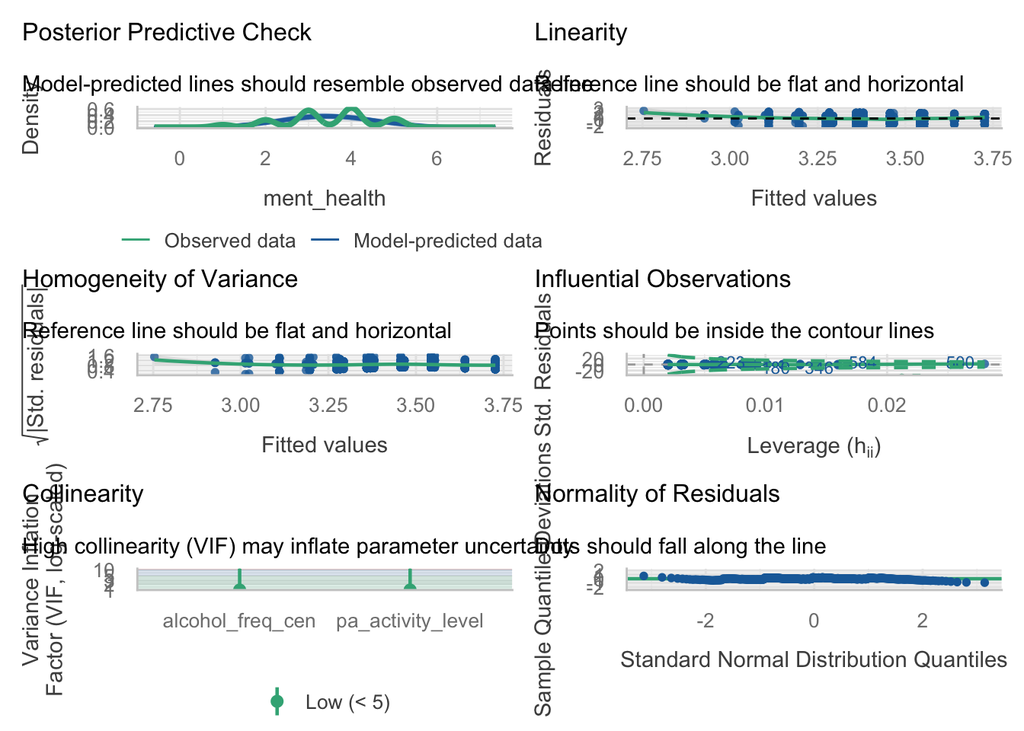

```r
performance::check_model(m2)
```

## Verificar los supuestos: NO se hace con la interacción (multicolinealidad)

```r
performance::check_collinearity(m1a)
```

| Term | VIF | VIF_CI_low | VIF_CI_high | SE_factor | Tolerance | Tolerance_CI_low | Tolerance_CI_high |
| --- | --- | --- | --- | --- | --- | --- | --- |
| alcohol_freq | 4.879867 | 4.240164 | 5.645866 | 2.209042 | 0.2049236 | 0.1771207 | 0.2358399 |
| pa_activity_level | 1.722439 | 1.551454 | 1.946438 | 1.312417 | 0.5805722 | 0.5137590 | 0.6445565 |
| alcohol_freq:pa_activity_level | 5.854060 | 5.070503 | 6.788449 | 2.419516 | 0.1708216 | 0.1473091 | 0.1972191 |

## Interpretar la interacción: Evaluar las pendientes simples (*Simple slope analysis*)

```r
modelbased::estimate_slopes(model = m2a,
                            trend = "alcohol_freq_cen",    # Predictora
                            by = "pa_activity_level")     # Moderadora
```

|  | pa_activity_level | Slope | SE | CI_low | CI_high | t | df | p |
| --- | --- | --- | --- | --- | --- | --- | --- | --- |
| 1 | 0 | 0.09563200 | 0.05508070 | -0.01254762 | 0.203811608 | 1.736216 | 586 | 8.305119e-02 |
| 2 | 1 | -0.05741769 | 0.02622328 | -0.10892075 | -0.005914623 | -2.189569 | 586 | 2.894910e-02 |
| 3 | 2 | -0.21046737 | 0.04166811 | -0.29230439 | -0.128630353 | -5.051042 | 586 | 5.877470e-07 |

- `pa_activity_level` como moderador
- El efecto de `alcohol_freq_cen` sobre `ment_health`, a diferentes valores de `pa_activity_level` [0 (`Inactive`), 1 (`Fairly active`) y 2 `Active`]

## Interpretar la interacción: Evaluar las pendientes simples de forma visual (*Simple slope analysis*)

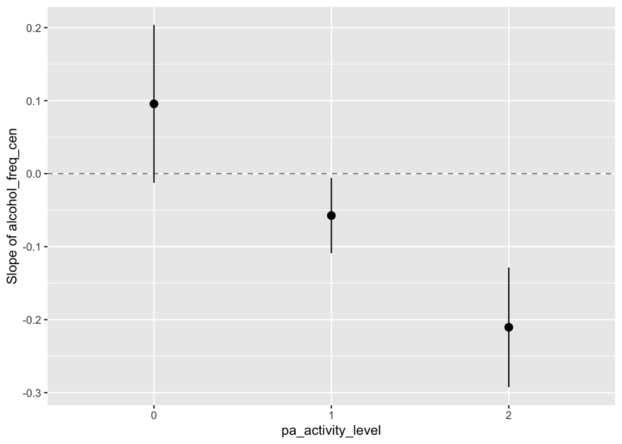

```r
modelbased::estimate_slopes(model = m2a,
                            trend = "alcohol_freq_cen",    # Predictora
                            by = "pa_activity_level")  |>
  plot()
```

## Interpretar la interacción: Visualizar las pendientes simples (*Simple slope analysis*)

- Las medias marginales ajustadas (*adjusted marginal means*) en `salud mental` (*dependiente*) por `frecuencia de consumo de alcohol` (*predictora*), en función de la `actividad física` (*moderadora*)

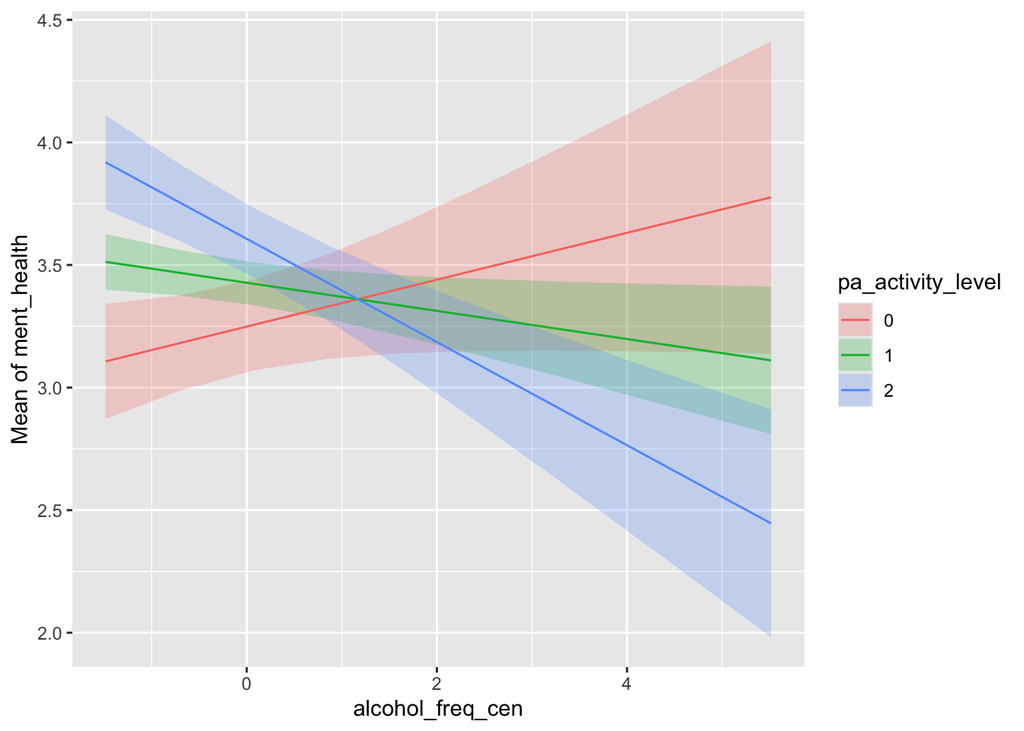

```r
modelbased::estimate_means(model = m2a,
                           by = c("alcohol_freq_cen", "pa_activity_level")) |>
  plot()
```

## Interpretar la interacción: Visualizar las pendientes simples (*Simple slope analysis*) (ajustado para publicación)

- Se puede adaptar la figura para formato de publicación (`ggplot`)

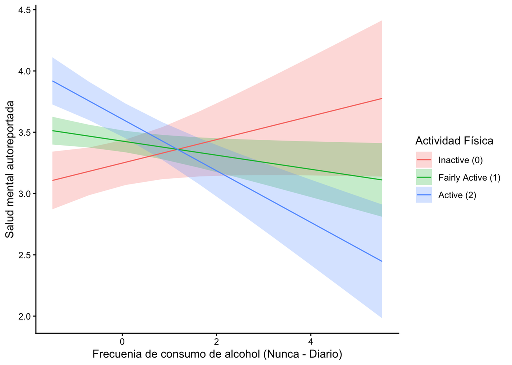

```r
modelbased::estimate_means(model = m2a,
                           by = c("alcohol_freq_cen", "pa_activity_level")) |>
  plot() +
  labs(x = "Frecuenia de consumo de alcohol (Nunca - Diario)",
       y = "Salud mental autoreportada",
       color = "Actividad Física",
       fill = "Actividad Física" ) +
  scale_color_discrete(labels = c("Inactive (0)","Fairly Active (1)","Active (2)")) +
  scale_fill_discrete(labels = c("Inactive (0)","Fairly Active (1)","Active (2)")) +
  theme_classic()
```

## Examinar la misma moderación desde otra perspectiva

#### Pendientes simples (*Simple slope analysis*): efectos simples

- `alcohol_freq_cen` como moderador
- Escogemos valores para probar la interacción (-1SD, Media, +1SD; pero puede ser cualquier valor de interés)

```r
ss_alcohol <- modelbased::estimate_slopes(model = m2a,
                            trend = "pa_activity_level",       # Predictora
                            by = "alcohol_freq_cen=[sd]")      # Moderadora

ss_alcohol
```

|  | alcohol_freq_cen | Slope | SE | CI_low | CI_high | t | df | p |
| --- | --- | --- | --- | --- | --- | --- | --- | --- |
| 1 | -1.702 | 0.43946438 | 0.09901083 | 0.24500508 | 0.6339237 | 4.4385486 | 586 | 1.082331e-05 |
| 2 | 0.000 | 0.17897382 | 0.07109910 | 0.03933374 | 0.3186139 | 2.5172446 | 586 | 1.209332e-02 |
| 3 | 1.702 | -0.08151674 | 0.10069186 | -0.27927762 | 0.1162441 | -0.8095663 | 586 | 4.185181e-01 |

## Pendientes Simples: Visualiza el tamaño del efecto (`b`)

- Visualiza la tabla anterior (los efectos de la actividad física sobre la salud mental, en función de la frecuencia de consumo de alcohol)

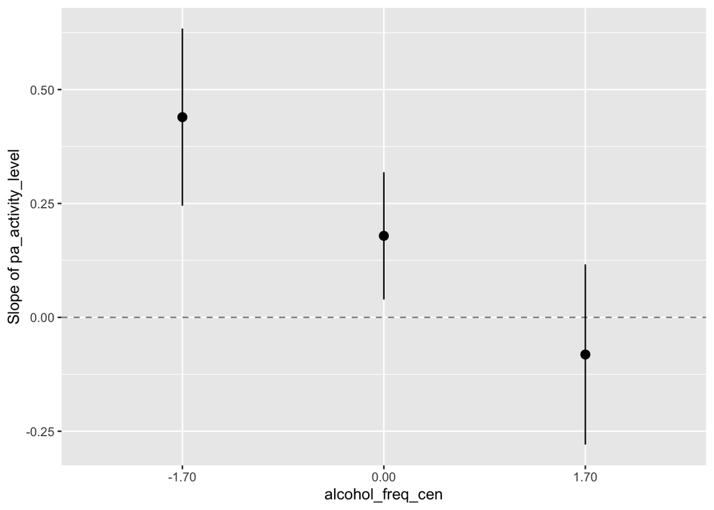

```r
ss_alcohol |>
  plot()
```

## Pendientes Simples: Ver las medias marginales ajustadas (`predicted outcome`)

```r
means_alcohol <- modelbased::estimate_means(model = m2a,
                           by = c("pa_activity_level","alcohol_freq_cen=[sd]"))

# ver los datos
means_alcohol
```

|  | pa_activity_level | alcohol_freq_cen | Mean | SE | CI_low | CI_high | t | df |
| --- | --- | --- | --- | --- | --- | --- | --- | --- |
| 1 | 0 | -1.702 | 3.085916 | 0.12757904 | 2.835348 | 3.336484 | 24.18827 | 586 |
| 2 | 0 | 0.000 | 3.248681 | 0.09408362 | 3.063899 | 3.433463 | 34.52972 | 586 |
| 3 | 0 | 1.702 | 3.411447 | 0.13781102 | 3.140783 | 3.682111 | 24.75453 | 586 |
| 4 | 1 | -1.702 | 3.525380 | 0.06148568 | 3.404621 | 3.646139 | 57.33660 | 586 |
| 5 | 1 | 0.000 | 3.427655 | 0.04440099 | 3.340451 | 3.514860 | 77.19772 | 586 |
| 6 | 1 | 1.702 | 3.329930 | 0.06436228 | 3.203521 | 3.456339 | 51.73730 | 586 |
| 7 | 2 | -1.702 | 3.964844 | 0.10437153 | 3.759857 | 4.169832 | 37.98779 | 586 |
| 8 | 2 | 0.000 | 3.606629 | 0.07212877 | 3.464967 | 3.748291 | 50.00264 | 586 |
| 9 | 2 | 1.702 | 3.248413 | 0.09784416 | 3.056246 | 3.440581 | 33.19987 | 586 |

## Pendientes Simples: Visualizar las medias marginales ajustadas (`predicted outcome`)

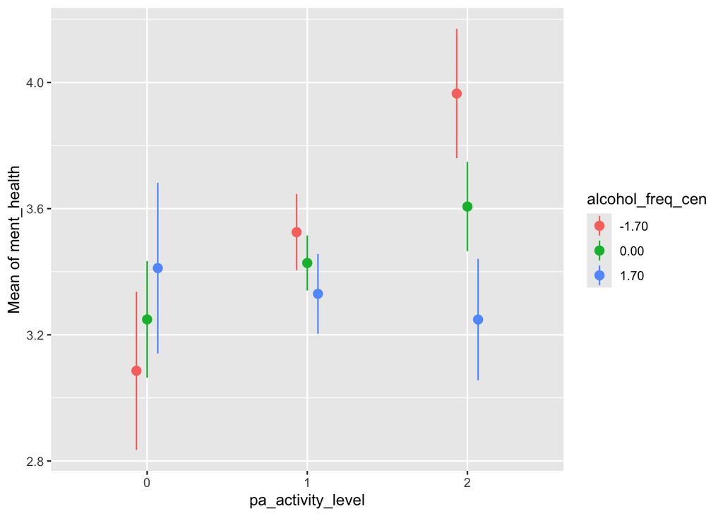

```r
means_alcohol |>
  plot()
```

## Pendientes Simples: Visualizar las medias marginales ajustadas (`predicted outcome`) (ajustado, para publicación)

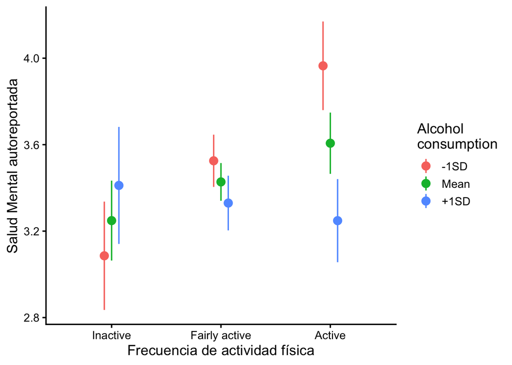

```r
means_alcohol |>
  plot() +
  labs(color = "Alcohol\nconsumption",
       y = "Salud Mental autoreportada",
       x = "Frecuencia de actividad física") +
  scale_x_discrete(labels = c("Inactive", "Fairly active", "Active")) +
  theme_classic(base_size = 14) +
  scale_color_discrete(labels = c("-1SD","Mean","+1SD"))
```

## Regiones de significancia `Johnson-Neyman`: Tabla

```r
jn_alcohol <- modelbased::estimate_slopes(model = m2a,
                            trend = "pa_activity_level",# Predictora
                            by = "alcohol_freq_cen",    # Moderadora
                            length = 100)
summary(jn_alcohol)
```

|  | Start | End | Direction | Confidence |
| --- | --- | --- | --- | --- |
| 1 | -1.485 | 0.212 | positive | Significant |
| 2 | 0.283 | 1.131 | positive | Not Significant |
| 3 | 1.202 | 2.970 | negative | Not Significant |
| 4 | 3.041 | 5.515 | negative | Significant |

## El tamaño del efecto de `pa_activity_level` a lo largo de 100 valores de `alcohol_freq_cen`. *NOTA: Asumiendo que fuera continua*

```r
jn_alcohol
```

|  | alcohol_freq_cen | Slope | SE | CI_low | CI_high | t | df | p |
| --- | --- | --- | --- | --- | --- | --- | --- | --- |
| 1 | -1.485 | 0.406252597 | 0.09303273 | 0.223534413 | 0.588970782 | 4.36677070 | 586 | 1.490981e-05 |
| 2 | -1.414 | 0.395386070 | 0.09117139 | 0.216323598 | 0.574448541 | 4.33673413 | 586 | 1.702596e-05 |
| 3 | -1.343 | 0.384519542 | 0.08934293 | 0.209048193 | 0.559990892 | 4.30386073 | 586 | 1.967006e-05 |
| 4 | -1.273 | 0.373806065 | 0.08762380 | 0.201711126 | 0.545901003 | 4.26603342 | 586 | 2.319768e-05 |
| 5 | -1.202 | 0.362939537 | 0.08596733 | 0.194097938 | 0.531781136 | 4.22183089 | 586 | 2.808495e-05 |
| 6 | -1.131 | 0.352073010 | 0.08435562 | 0.186396854 | 0.517749165 | 4.17367600 | 586 | 3.452136e-05 |
| 7 | -1.061 | 0.341359532 | 0.08283668 | 0.178666607 | 0.504052458 | 4.12087436 | 586 | 4.318598e-05 |
| 8 | -0.990 | 0.330493005 | 0.08135286 | 0.170714326 | 0.490271683 | 4.06246333 | 586 | 5.516974e-05 |
| 9 | -0.919 | 0.319626477 | 0.07998848 | 0.162527460 | 0.476725494 | 3.99590623 | 586 | 7.266354e-05 |
| 10 | -0.848 | 0.308759950 | 0.07868926 | 0.154212632 | 0.463307268 | 3.92378766 | 586 | 9.750574e-05 |

[output cut: 90 more lines]

## Regiones de significancia `Johnson-Neyman`: Visualización

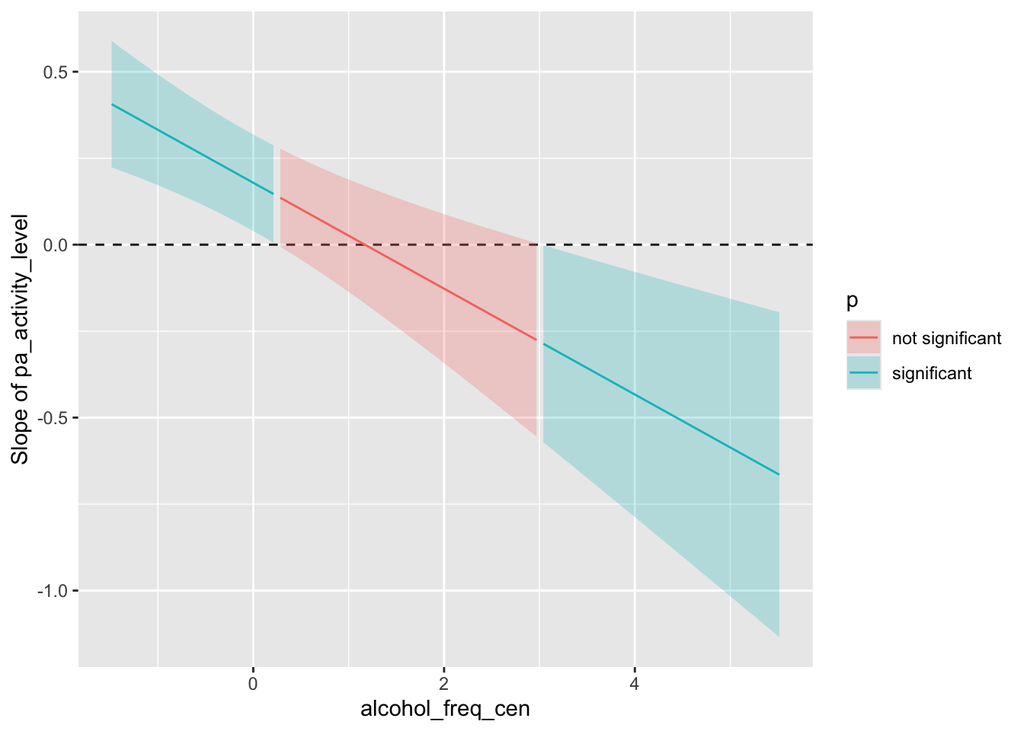

```r
jn_alcohol |>  # efectos a -1SD, la media y +1SD
  plot()
```

## Regiones de significancia `Johnson-Neyman`: Figura (adaptada para publicación)

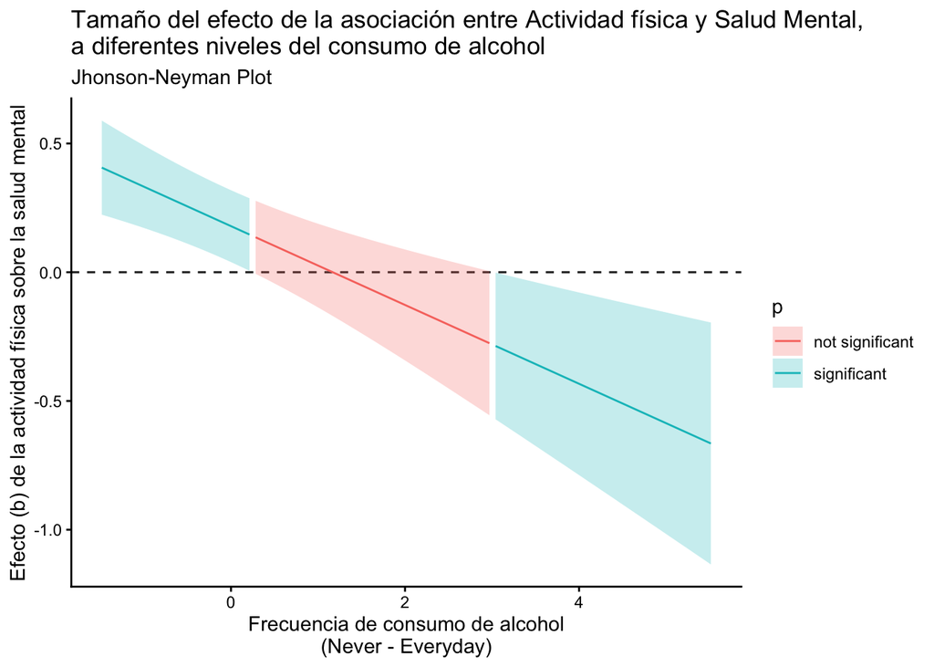

```r
jn_alcohol |>
  plot() +
  labs(x = "Frecuencia de consumo de alcohol\n(Never - Everyday)",
       y = "Efecto (b) de la actividad física sobre la salud mental",
       title = "Tamaño del efecto de la asociación entre Actividad física y Salud Mental,\na diferentes niveles del consumo de alcohol",
       subtitle = "Jhonson-Neyman Plot") +
    theme_classic()
```

# Ejercicio

## Ejercicio: moderación con salud física (20 minutos)

En este ejercicio vamos a evaluar si la relación entre **conexión social** y **salud física** depende de la **etnicidad**.

- Variable dependiente: `phys_health`
- Variable independiente: `social_connect`
- Moderadora: `ethnicity_black`
- Covariables: `gender_female`, `age_group`

### Tareas

1. Preparar las variables necesarias: centrar `social_connect`
2. Estimar un modelo de regresión con efectos simples: predictoras
3. Estimar un modelo con interacción
4. Presentar los resultados en una tabla.
5. Evaluar las pendientes simples.
6. Escribir una conclusión breve.

## Solución 1: preparar las variables

```r
data_ex <- data |>
  mutate(
    # Centrar conexión social
    social_connect_cen = as.numeric(scale(social_connect, center = TRUE,scale = FALSE)),
    # Centrar edad/grupo de edad para facilitar la interpretación
    age_group_cen = as.numeric(scale(age_group,center = TRUE,scale = FALSE)))

glimpse(data_ex)
```

```
Rows: 590
Columns: 70
$ id                             <dbl> 1, 2, 3, 4, 5, 6, 7, 8, 9, 10, 11, 12, …
$ age_group                      <dbl> 1, 1, 1, 1, 1, 1, 2, 4, 1, 1, 1, 1, 1, …
$ gender                         <dbl> 2, 1, 1, 1, 1, 2, 1, 1, 2, 2, 2, 2, 2, …
$ sexual_orientation             <dbl> 1, 2, 1, 3, 1, 1, 1, 1, 1, 1, 1, 1, 1, …
$ ethnicity                      <dbl> 1, 1, 1, 2, 1, 3, 1, 1, 1, 3, 1, 1, 1, …
$ study_mode                     <dbl> 1, 1, 1, 1, 1, 1, 1, 2, 1, 1, 1, 1, 1, …
$ study_level                    <dbl> 3, 3, 3, 3, 2, 6, 4, 3, 1, 2, 1, 1, 1, …
$ living_situation               <dbl> 1, 2, 1, 3, 2, 4, 3, 3, 1, 2, 4, 1, 1, …
$ phys_health                    <dbl> 3, 4, 4, 3, 4, 5, 5, 1, 4, 4, 4, 5, 5, …
$ ment_health                    <dbl> 4, 3, 2, 4, 3, 3, 2, 1, 4, 4, 3, 5, 3, …
$ social_connect                 <dbl> 4, 3, 1, 1, 2, 3, 2, 4, 4, 3, 3, 3, 2, …
$ sitting_weekday_hours          <dbl> 8, 5, 7, 9, NA, 5, 11, 13, 6, 5, 12, 6,…
$ sleep_quality                  <dbl> 8, 7, 4, 7, 2, 5, 3, 8, 7, 2, 9, 7, 3, …
```

[output cut: 57 more lines]

## Solución 2: modelo con efectos simples

```r
m_simple <- lm(phys_health ~ social_connect_cen + ethnicity_black +
    gender_female + age_group_cen, data = data_ex)

parameters::model_parameters(m_simple)
```

| Parameter | Coefficient | SE | CI | CI_low | CI_high | t | df_error | p |
| --- | --- | --- | --- | --- | --- | --- | --- | --- |
| (Intercept) | 3.899144141 | 0.06837116 | 0.95 | 3.76484360 | 4.03344469 | 57.0290789 | 550 | 4.485842e-233 |
| social_connect_cen | 0.204648907 | 0.03598442 | 0.95 | 0.13396519 | 0.27533262 | 5.6871530 | 550 | 2.099824e-08 |
| ethnicity_black | 0.258932769 | 0.08133411 | 0.95 | 0.09916927 | 0.41869627 | 3.1835692 | 550 | 1.536978e-03 |
| gender_female | -0.121175638 | 0.07662033 | 0.95 | -0.27167992 | 0.02932864 | -1.5815077 | 550 | 1.143369e-01 |
| age_group_cen | 0.006387751 | 0.04156055 | 0.95 | -0.07524908 | 0.08802458 | 0.1536975 | 550 | 8.779047e-01 |

## Solución 3: modelo con interacción

```r
m_interaction <- lm(
  phys_health ~ social_connect_cen * ethnicity_black +
    gender_female + age_group_cen,
  data = data_ex)

parameters::model_parameters(m_interaction)
```

| Parameter | Coefficient | SE | CI | CI_low | CI_high | t | df_error | p |
| --- | --- | --- | --- | --- | --- | --- | --- | --- |
| (Intercept) | 3.9019017 | 0.06771389 | 0.95 | 3.76889170 | 4.03491174 | 57.6233568 | 549 | 5.860114e-235 |
| social_connect_cen | 0.1327966 | 0.04131776 | 0.95 | 0.05163638 | 0.21395689 | 3.2140325 | 549 | 1.385708e-03 |
| ethnicity_black | 0.2410186 | 0.08071511 | 0.95 | 0.08247035 | 0.39956683 | 2.9860405 | 549 | 2.952220e-03 |
| gender_female | -0.1344125 | 0.07597615 | 0.95 | -0.28365208 | 0.01482699 | -1.7691413 | 549 | 7.742544e-02 |
| age_group_cen | -0.0157134 | 0.04165765 | 0.95 | -0.09754128 | 0.06611448 | -0.3772033 | 549 | 7.061683e-01 |
| social_connect_cen:ethnicity_black | 0.2743973 | 0.07985388 | 0.95 | 0.11754073 | 0.43125380 | 3.4362421 | 549 | 6.344926e-04 |

## Solución 4: comparar modelos en una tabla

```r
parameters::compare_parameters(m_simple, m_interaction) |>
  parameters::display()
```

| Parameter | m_simple | m_interaction |
| --- | --- | --- |
| (Intercept) | 3.90 ( 3.76, 4.03) | 3.90 ( 3.77, 4.03) |
| social connect cen | 0.20 ( 0.13, 0.28) | 0.13 ( 0.05, 0.21) |
| ethnicity black | 0.26 ( 0.10, 0.42) | 0.24 ( 0.08, 0.40) |
| gender female | -0.12 (-0.27, 0.03) | -0.13 (-0.28, 0.01) |
| age group cen | 6.39e-03 (-0.08, 0.09) | -0.02 (-0.10, 0.07) |
| social connect cen × ethnicity black |  | 0.27 ( 0.12, 0.43) |
| Observations | 555 | 555 |

```r
performance::compare_performance(m_simple,m_interaction)
```

| Name | Model | AIC | AIC_wt | AICc | AICc_wt | BIC | BIC_wt | R2 | R2_adjusted | RMSE | Sigma |
| --- | --- | --- | --- | --- | --- | --- | --- | --- | --- | --- | --- |
| m_simple | lm | 1368.729 | 0.007354032 | 1368.882 | 0.007544292 | 1394.643 | 0.06033329 | 0.08989415 | 0.0832752 | 0.8214696 | 0.8251951 |
| m_interaction | lm | 1358.919 | 0.992645968 | 1359.123 | 0.992455708 | 1389.151 | 0.93966671 | 0.10905635 | 0.1009421 | 0.8127756 | 0.8172050 |

## Solución 5: tabla de resultados para reportar

```r
sjPlot::tab_model(
  m_simple,
  m_interaction,
  show.se = TRUE,
  show.stat = TRUE,
  pred.labels = c(
    "(Intercept)",
    "Conexión social",
    "Etnia: Black",
    "Género: mujer",
    "Grupo de edad",
    "Conexión social x Black"
  ),
  dv.labels = c(
    "Efectos simples",
    "Interacción"
  )
)
```

|  | Efectos simples |  |  |  |  | Interacción |  |  |  |  |
| --- | --- | --- | --- | --- | --- | --- | --- | --- | --- | --- |
| Predictors | Estimates | std. Error | CI | Statistic | p | Estimates | std. Error | CI | Statistic | p |
| (Intercept) | 3.90 | 0.07 | 3.76 – 4.03 | 57.03 | **<0.001** | 3.90 | 0.07 | 3.77 – 4.03 | 57.62 | **<0.001** |
| Conexión social | 0.20 | 0.04 | 0.13 – 0.28 | 5.69 | **<0.001** | 0.13 | 0.04 | 0.05 – 0.21 | 3.21 | **0.001** |
| Etnia: Black | 0.26 | 0.08 | 0.10 – 0.42 | 3.18 | **0.002** | 0.24 | 0.08 | 0.08 – 0.40 | 2.99 | **0.003** |
| Género: mujer | -0.12 | 0.08 | -0.27 – 0.03 | -1.58 | 0.114 | -0.13 | 0.08 | -0.28 – 0.01 | -1.77 | 0.077 |
| Grupo de edad | 0.01 | 0.04 | -0.08 – 0.09 | 0.15 | 0.878 | -0.02 | 0.04 | -0.10 – 0.07 | -0.38 | 0.706 |
| Conexión social x Black |  |  |  |  |  | 0.27 | 0.08 | 0.12 – 0.43 | 3.44 | **0.001** |
| Observations | 555 |  |  |  |  | 555 |  |  |  |  |
| R<sup>2</sup> / R<sup>2</sup> adjusted | 0.090 / 0.083 |  |  |  |  | 0.109 / 0.101 |  |  |  |  |

## Solución 6: pendientes simples

```r
ss_ethnicity <- modelbased::estimate_slopes(
  m_interaction,
  trend = "social_connect_cen",
  by = "ethnicity_black=[0,1]"
)

ss_ethnicity
```

|  | ethnicity_black | Slope | SE | CI_low | CI_high | t | df | p |
| --- | --- | --- | --- | --- | --- | --- | --- | --- |
| 1 | 0 | 0.1327966 | 0.04130927 | 0.05165306 | 0.2139402 | 3.214693 | 549 | 1.382583e-03 |
| 2 | 1 | 0.4071939 | 0.06886203 | 0.27192859 | 0.5424592 | 5.913184 | 549 | 5.902038e-09 |

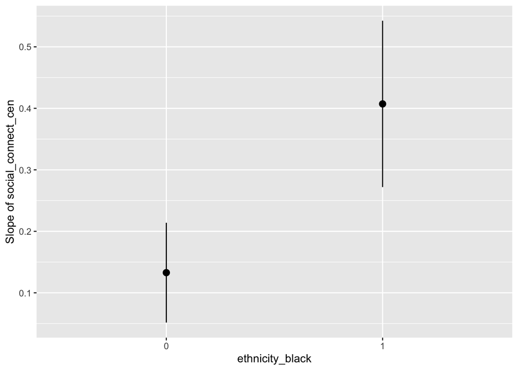

```r
ss_ethnicity |>
  plot()
```

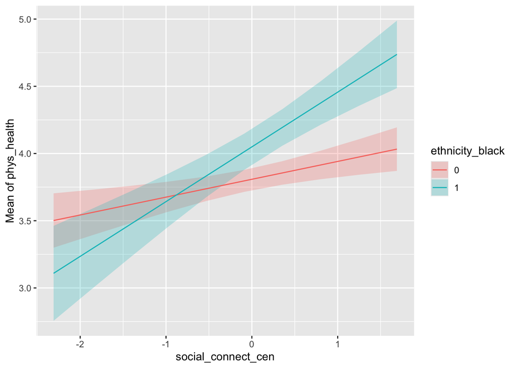

```r
modelbased::estimate_means(model = m_interaction,
                           by = c("social_connect_cen", "ethnicity_black")) |>
  plot()
```

## Solución 7: conclusión

```r
parameters::model_parameters(m_interaction) |>
  parameters::display()
```

| Parameter | Coefficient | SE | 95% CI | t(549) | p |
| --- | --- | --- | --- | --- | --- |
| (Intercept) | 3.90 | 0.07 | (3.77, 4.03) | 57.62 | < .001 |
| social connect cen | 0.13 | 0.04 | (0.05, 0.21) | 3.21 | 0.001 |
| ethnicity black | 0.24 | 0.08 | (0.08, 0.40) | 2.99 | 0.003 |
| gender female | -0.13 | 0.08 | (-0.28, 0.01) | -1.77 | 0.077 |
| age group cen | -0.02 | 0.04 | (-0.10, 0.07) | -0.38 | 0.706 |
| social connect cen × ethnicity black | 0.27 | 0.08 | (0.12, 0.43) | 3.44 | < .001 |

### Conclusión orientativa

- El modelo con efectos simples evalúa si la **conexión social** y la **etnicidad** se asocian con la **salud física**, controlando por género y edad.
- El modelo con interacción evalúa si la asociación entre **conexión social** y **salud física** es diferente para estudiantes Black y White.
- Si el término `social_connect_cen:ethnicity_black` es estadísticamente significativo, concluimos que la asociación entre conexión social y salud física depende de la etnicidad.
- Si no es significativo, concluimos que no hay evidencia suficiente de moderación.
- Como `ethnicity_black` es dicotómica, la interpretación principal debe basarse en las **pendientes simples**.

## Resumen

- La **moderación** permite evaluar si una relación entre dos variables cambia según una tercera variable.
- Estadísticamente, la moderación se analiza mediante una **interacción**.
- Una interacción significativa indica que el efecto de una variable **depende de otra**.
- Los efectos principales deben interpretarse con cuidado cuando hay interacción.
- Centrar las variables continuas ayuda a interpretar mejor los resultados.
- Para entender la interacción, no basta con mirar el coeficiente: hay que examinar las **pendientes simples** o los **efectos marginales**.
- El objetivo final es responder:  
  **¿cuándo, para quién o bajo qué condiciones ocurre el efecto?**